# Regression model for recurrent event data

Sy Han (Steven) Chiou

2023-07-10

The regression model implemented in the **`reReg`** package accommodate informative censoring via the use of a subject-specific frailty variable. In contrast to existing frailty models, the implemented estimation procedure does not require distributional information on the frailty variable. Using the borrowing-strength approach in the estimating procedure, our model allows users to specify any combination of the sub-models between the recurrent event process and the terminal events when they are fitted jointly.

In this vignette, we demonstrate how to use the `reReg()` function in the **`reReg`** package to fit semiparametric regression models to recurrent event data.

## Notations

Let $N(t)$ be the number of recurrent events occurring over the interval $[0, t]$ and $D$ be the failure time of interest subjects to right censoring by $C$. Define the composite censoring time $Y = \min(D, C, \tau)$ and the failure event indicator $\Delta = I\{D\le \min(C, \tau)\}$, where $\tau$ is the maximum follow-up time. We assume the recurrent event process $N(\cdot)$ is observed up to $Y$. Let $X$ be a $p$-dimensional covariate vector. Consider a random sample of $n$ subjects, the observed data are independent and identically distributed (iid) copies of $\{Y_i, \Delta_i, X_i, N_i(t), 0\le t\le Y_i\}$, where the subscript $i$ denotes the index of a subject for $i= 1, \ldots, n$. Let $m_i = N_i(Y_i)$ be the number of recurrent events the $i$th subject experienced before time $Y_i$, then the jump times of $N_i(t)$ give the observed recurrent event times $t_{i1}, \ldots, t_{im_i}$ when $m_i > 0$. Thus, the observed data can also be expressed as iid copies of $\{Y_i, \Delta_i, X_i, m_i, (t_{i1}, \ldots, t_{m_i})\}$. The primary interests in recurrent event data analysis is in making inference about the recurrent event process and the failure event and understanding the corresponding covariate effects.

## Model assumption

We assume a generalized joint frailty scale-change model for the rate function of the recurrent event process and the hazard function of the failure time formulated as follow:
$$\begin{equation}
\begin{cases}
\lambda(t) = \displaystyle Z\lambda_0(te^{X^\top\alpha})e^{X^\top\beta},&\\
h(t) = \displaystyle Zh_0(te^{X^\top\eta})e^{X^\top\theta}, &t\in[0, \tau],
\end{cases}
\end{equation}$$
where $Z$ is a latent shared frailty variable to account for association between the two types of outcomes, $\lambda_0(\cdot)$ is the baseline rate function, $h_0(\cdot)$ is the baseline hazard function, and the regression coefficients $(\alpha, \eta)$ and $(\beta, \theta)$ correspond to the shape and size parameters of the rate function and hazard function, respectively. In contrast to many shared-frailty models that require a parametric assumption, following the idea of Wang, Qin, and Chiang (2001), the `reReg()` function implements semiparametric estimation procedures that do not require the knowledge about the frailty distribution. As a result, the dependence between recurrent events and failure event is left unspecified and the proposed implementations accommodate informative censoring. The `reReg()` function fits the recurrent event data under the above joint model setting. The arguments of `reReg()` are as follows

```r
> library(reReg)
> args(reReg)
```

```
function (formula, data, subset, model = "cox", B = 0, se = c("boot",
    "sand"), control = list())
NULL
```

- `formula` a formula object, with the response on the left of a “~” operator, and the predictors on the right. The response must be a recurrent event survival object as returned by function `Recur`. See the vignette on [Visualization of recurrent event data](https://www.sychiou.com/reReg/articles/reReg-plots.html) or [Introduction to formula response function `Recur()`](https://wenjie-stat.me/reda/articles/reda-recur) for examples in creating `Recur` objects.
- `data` an optional data frame in which to interpret the variables occurring in the `formula`.
- `B` a numeric value specifies the number of bootstrap (or resampling) for variance estimation. When `B = 0`, variance estimation will not be performed.
- `model` a character string specifying the underlying model.
- `se` a character string specifying the method for standard error estimation.
- `control` a list of control parameters.

#### Specifying model via the `model` argument

When the interest is the covariate effects on the risk of recurrent events and the terminal event is treated as nuisances, `model = "cox"` and `model = "gsc"` give the Cox-type model and the generalized scale-change rate model considered in Wang, Qin, and Chiang (2001) and Xu et al. (2020), respectively. When the recurrent event process and the terminal events are modeled jointly, the types of rate function and hazard function can be specified simultaneously in `model` separated by ```|`’’. The model types for the hazard function are `cox`, `ar`, `am`, and `gsc`. For examples, the joint frailty Cox-type model of Huang and Wang (2004) and the joint frailty accelerated mean model of Xu et al. (2017) can be called by `model = "cox|cox"` and `model = "am|am"`, respectively. Depending on the application, users can specify different model types for the rate function and the hazard function. For example, `model = "cox|ar"` postulate a Cox-type proportional model for the recurrent event rate function and an accelerated rate model for the terminal event hazard function, or $\alpha = \theta = 0$ in (1).

#### Variance estimation

The nonparametric bootstrap method for clustered data is adopted to estimate the standard errors of the estimators. The bootstrap samples are formed by resampling the subjects with replacement of the same size from the original data. The above estimating procedures are then applied to each bootstrap sample to provide one draw of the bootstrap estimate. With a large number of replicates, the asymptotic variance matrices are estimated by the sample variance of the bootstrap estimates. In an attempt to overcome the computational burden in bootstrap variance estimation, parallel computing techniques based on methods in the `parallel` package will be applied when `boot.parallel = TRUE}`. The number of CPU cores used in the parallel computing is controlled by the argument `boot.parCl}`, whose default value is half of the total number of CPU cores available on the current host identified by `parallel::detectCores() \%/\% 2}`. When fitting the generalized scale-change rate model of Xu et al. (2020), e.g., with `model = "sc"`, an efficient resampling-based sandwich estimator is also available via `se = "sand"`. The number of bootstrap or resampling is controlled by the argument `B`. When `B = 0` (default), the variance estimation procedure will not be performed and only the point estimates will be returned, which can be useful when the variance estimation is time consuming. Future work will be devoted to generalize the efficient resampling-based sandwich estimator to all the sub-models.

#### The `control` list

The complete `control` list consists of the following parameters:

- `eqType` is a character string used to specify whether the log-rank-type (`"logrank"`) or the Gehan-type (`"gehan"`) estimating equation is used in the estimating procedure.
- `solver` is a character string used to specify the equation solver used for root search; the available options are `BBsolve`, `dfsane`, `BBoptim`, and `optim` (the first three options loads the corresponding equation solver from package `BB` (Varadhan and Gilbert 2009)).
- `tol` is a numerical value used to specify the absolute error tolerance in solving the estimating equations. The default value is $10^{-7}$.
- `ini` is a list of initial values used in the root-finding algorithms. The list members `alpha`, `beta`, `eta`, and `theta` correspond to the parameters $\alpha$, $\beta$, $\eta$, and $\theta$ in Model~, respectively. The default values for these initial values are zeros.
- `boot.parallel` is an logical value indicating whether parallel computation will be applied when `se = "boot"` is called.
- `boot.parCl` is an integer value specifying the number of CPU cores to be used when `parallel = TRUE`. The default value is half the CPU cores on the current host.

The default equation solver (`"BB::dfsane"`) uses the derivative-free Barzilai-Borwein spectral approach for solving nonlinear equations implemented in `dfsane()` from the package `BB` (Varadhan and Gilbert 2009). Setting `solver = "BB::BBsolve"` calls the wrapper function `BBsolve()` in the `BB` package to locate a root with different Barzilai-Borwein step-lengths, non-monotonicity parameters, and initialization approaches. Based on our observation, the `"BB::BBsolve"` algorithm generally exhibited more reliable convergence but the `solver = "BB::dfsane"` algorithm provides a better balance between convergence and speed. The alternative options, `solver = "BB::BBoptim"` and `solver = "optim"`, attempts to identify roots by minimizing the $\ell_2$-norm of the estimating functions. The options `solver = "BB::BBoptim"` and `solver = "optim"` call the `BBoptim()` function from the package `BB` and the base function `optim()`, respectively.

## Examples

We will illustrate the usage of `reReg` with simulated data generated from the `simGSC()` function. Readers are referred to the vignette on [Simulating recurrent event data](https://www.sychiou.com/reReg/articles/reReg-sims.html) for using `simGSC()` to generate recurrent event data.

#### Joint Cox model of Huang and Wang (2004)

A simulated data following the joint Cox model can be generated by

```r
> set.seed(1); datCox <- simGSC(200, summary = TRUE)
```

```
Call:
simGSC(n = 200, summary = TRUE)

Summary:
Sample size:                                    200
Number of recurrent event observed:             710
Average number of recurrent event per subject:  3.55
Proportion of subjects with a terminal event:   0.585
Median time-to-terminal event:                  10.078
```

```r
> fit.cox <- reReg(Recur(t.start %to% t.stop, id, event, status) ~ x1 + x2,
+                  B = 200, data = datCox, model = "cox|cox")
> summary(fit.cox)
```

```
Call:
reReg(formula = Recur(t.start %to% t.stop, id, event, status) ~
    x1 + x2, data = datCox, model = "cox|cox", B = 200)

Recurrent event process:
   Estimate   StdErr z.value   p.value
x1 -0.99760  0.15371 -6.4902 8.570e-11 ***
x2 -1.08084  0.14564 -7.4215 1.158e-13 ***

Terminal event:
   Estimate  StdErr z.value   p.value
x1  1.29806 0.28137  4.6134 3.962e-06 ***
x2  1.33244 0.32677  4.0777 4.549e-05 ***
```

The baseline functions can be plotted via `plot()`:

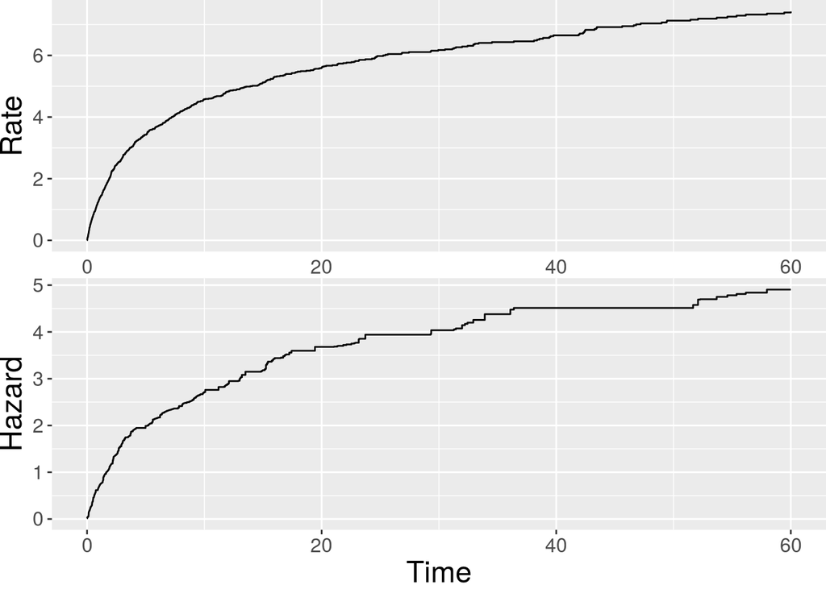

```r
> plot(fit.cox)
```

#### Joint accelerated mean model of Xu et al. (2017)

A simulated data following the joint accelerated mean model can be generated by

```r
> set.seed(1)
> par0 <- list(alpha = c(1, 1), beta = c(1, 1), eta = -c(1, 1), theta = -c(1, 1))
> datam <- simGSC(200, par = par0, summary = TRUE)
```

```
Call:
simGSC(n = 200, summary = TRUE, para = par0)

Summary:
Sample size:                                    200
Number of recurrent event observed:             1122
Average number of recurrent event per subject:  5.61
Proportion of subjects with a terminal event:   0.4
```

The underlying true model has the form:
$$\begin{cases}
\lambda(t) = Z \lambda_0(te^{X_1 + X_2})e^{X_1 + X_2}, &\\
h(t) = Z h_0(te^{-X_1 - X_2})e^{-X_1 - X_2}, & t\in[0, 60].
\end{cases}$$
The model fit is

```r
> fit.am <- reReg(Recur(t.start %to% t.stop, id, event, status) ~ x1 + x2,
+                 B = 200, data = datam, model = "am|am")
> summary(fit.am)
```

```
Call:
reReg(formula = Recur(t.start %to% t.stop, id, event, status) ~
    x1 + x2, data = datam, model = "am|am", B = 200)

Recurrent event process:
   Estimate  StdErr z.value   p.value
x1  0.75204 0.25470  2.9527   0.00315 **
x2  1.10920 0.27356  4.0547 5.019e-05 ***

Terminal event:
   Estimate   StdErr z.value  p.value
x1 -1.74571  0.56071 -3.1134 0.001849 **
x2 -1.18901  0.57962 -2.0514 0.040231 *
```

The baseline functions can be plotted via `plot()`:

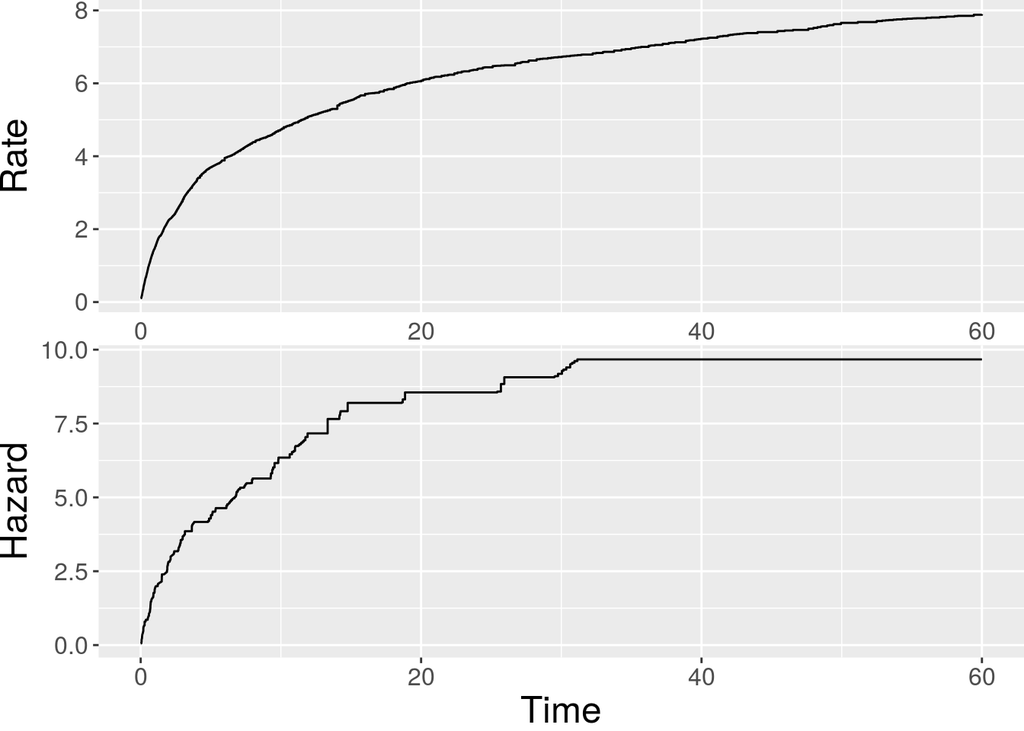

```r
> plot(fit.am)
```

#### Joint Cox/accelerated rate model

A simulated model following a special case of the generalized scale-change model where the rate function has a Cox structure and the hazard function has an accelerated rate model structure can be generated by

```r
> set.seed(1)
> par0 <- list(eta = c(1, 1), theta = c(0, 0))
> datCoxAr <- simGSC(200, par = par0, summary = TRUE)
```

```
Call:
simGSC(n = 200, summary = TRUE, para = par0)

Summary:
Sample size:                                    200
Number of recurrent event observed:             678
Average number of recurrent event per subject:  3.39
Proportion of subjects with a terminal event:   0.34
```

The underlying true model has the form:
$$\begin{cases}
\lambda(t) = Z \lambda_0(t)e^{-X_1 - X_2}.&\\
h(t) = Z h_0(te^{X_1 + X_2})& t\in[0, 60].
\end{cases}$$
The model fit is

```r
> fit.CoxAr <- reReg(Recur(t.start %to% t.stop, id, event, status) ~ x1 + x2,
+                    B = 200, data = datCoxAr, model = "cox|ar")
> summary(fit.CoxAr)
```

```
Call:
reReg(formula = Recur(t.start %to% t.stop, id, event, status) ~
    x1 + x2, data = datCoxAr, model = "cox|ar", B = 200)

Recurrent event process:
   Estimate   StdErr z.value   p.value
x1 -0.94955  0.15750 -6.0289 1.651e-09 ***
x2 -0.88239  0.16338 -5.4010 6.627e-08 ***

Terminal event:
   Estimate  StdErr z.value p.value
x1  1.40308 0.56318  2.4913 0.01273 *
x2  1.06758 0.58527  1.8241 0.06814 .
```

The baseline functions can be plotted via `plot()`:

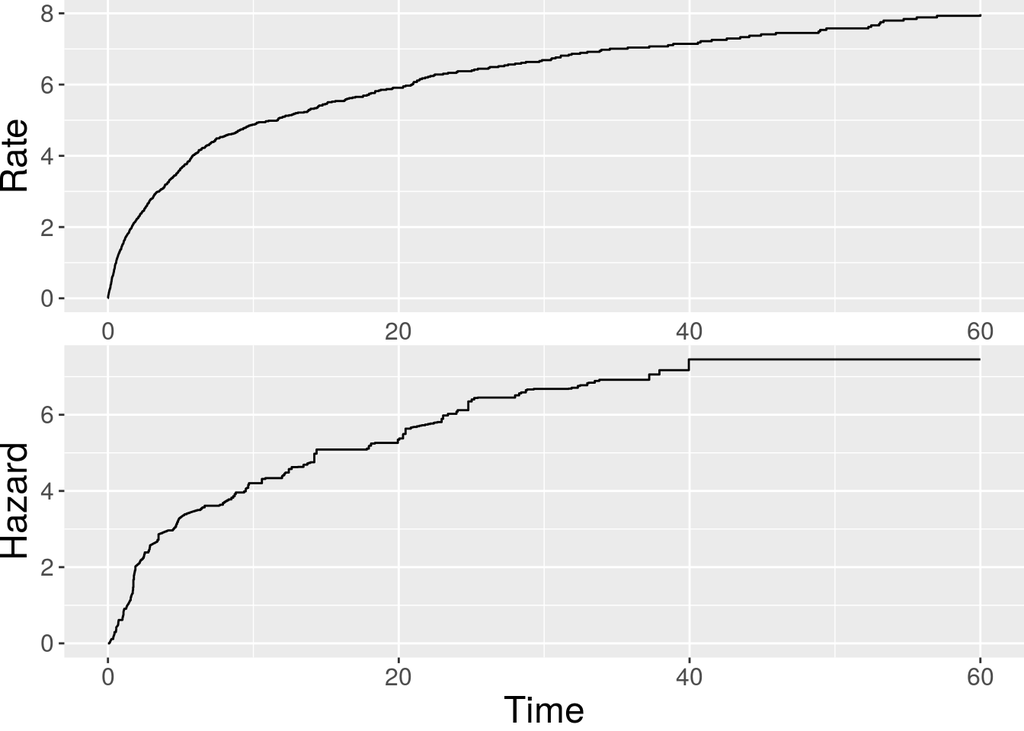

```r
> plot(fit.CoxAr)
```

## Other popular methods

Some methods that assumes `Z = 1` and requires independent censoring are also implemented in `reReg`. These includes the methods proposed by Lin et al. (2000), Ghosh and Lin (2002), and Ghosh and Lin (2003), that can be called by specifying `model = "cox.LWYY"`, `model = "cox.GL"`, and `model = "am.GL"`, respectively.

It is also worth noting that methods in multi-state models could also be applied to analyze recurrent events data. See the vignette on [Multi-state models and competing risks](https://cran.r-project.org/web/packages/survival/vignettes/compete.pdf) for more details.

## Reference

Ghosh, Debashis, and D. Y. Lin. 2002. “Marginal Regression Models for Recurrent and Terminal Events.” *Statistica Sinica* 12 (3): 663–88.

———. 2003. “Semiparametric Analysis of Recurrent Events Data in the Presence of Dependent Censoring.” *Biometrics* 59 (4): 877–85.

Huang, Chiung-Yu, and Mei-Cheng Wang. 2004. “Joint Modeling and Estimation for Recurrent Event Processes and Failure Time Data.” *Journal of the American Statistical Association* 99 (468): 1153–65.

Lin, D. Y., L. J. Wei, I. Yang, and Z. Ying. 2000. “Semiparametric Regression for the Mean and Rate Functions of Recurrent Events.” *Journal of the Royal Statistical Society: Series B* 62 (4): 711–30.

Varadhan, Ravi, and Paul Gilbert. 2009. “BB: An R Package for Solving a Large System of Nonlinear Equations and for Optimizing a High-Dimensional Nonlinear Objective Function.” *Journal of Statistical Software* 32 (4): 1–26. http://www.jstatsoft.org/v32/i04/.

Wang, Mei-Cheng, Jing Qin, and Chin-Tsang Chiang. 2001. “Analyzing Recurrent Event Data with Informative Censoring.” *Journal of the American Statistical Association* 96 (455): 1057–65.

Xu, Gongjun, Sy Han Chiou, Chiung-Yu Huang, Mei-Cheng Wang, and Jun Yan. 2017. “Joint Scale-Change Models for Recurrent Events and Failure Time.” *Journal of the American Statistical Association* 112 (518): 794–805.

Xu, Gongjun, Sy Han Chiou, Jun Yan, Kieren Marr, and Chiung-Yu Huang. 2020. “Generalized Scale-Change Models for Recurrent Event Processes Under Informative Censoring.” *Statistica Sinica* 30: 1773–95.